# MZES SSDL: Computationally Analyzing Politicians’ Body Language Using Pose Estimation

Oliver Rittmann

October 16, 2024

# Load movenet prediction output (pose estimation) into R

The pose estimation data comes in .json format. We have two files, one for each video.

```r
files <- list.files(here("movenet_results"))

json_files <- files[str_detect(files, ".json")]

json_files
```

```
[1] "speech1_gabriela_heinrich.json" "speech2_klaus_ernst.json"
```

Let’s have a look at how the data looks like

```r
#head(speech1_raw)
dim(speech1_raw)
```

```
[1] 274   1   1  17   3
```

Dimensions 274 x 1 x 1 x 17 x 3 – Any ideas what these dimensions are about?

```r
# the first frame
speech1_raw[1,,,,]
```

```
           [,1]      [,2]       [,3]
 [1,] 0.3828655 0.5242524 0.68463719
 [2,] 0.3538715 0.5414523 0.75235844
 [3,] 0.3582214 0.5031287 0.48237407
 [4,] 0.3297369 0.5690745 0.69024754
 [5,] 0.3400428 0.4759488 0.75820732
 [6,] 0.3940416 0.6355466 0.90980828
 [7,] 0.4116655 0.4349169 0.86186630
 [8,] 0.5216534 0.6782555 0.78337336
 [9,] 0.5355401 0.3803662 0.79445451
[10,] 0.6526011 0.6498522 0.74373788
[11,] 0.6306298 0.3373373 0.71716160
[12,] 0.6974007 0.6186860 0.67185098
[13,] 0.6894653 0.4781892 0.77422142
[14,] 0.5340295 0.6774333 0.02469357
[15,] 0.7561160 0.4362402 0.02170779
[16,] 0.7344654 0.5591633 0.01254712
[17,] 0.7249266 0.4822194 0.01522222
```

```r
# the second frame
speech1_raw[2,,,,]
```

```
           [,1]      [,2]       [,3]
 [1,] 0.3862496 0.5251055 0.67808115
 [2,] 0.3568694 0.5423815 0.66246796
 [3,] 0.3613199 0.5044520 0.63965297
 [4,] 0.3316347 0.5683912 0.71318316
 [5,] 0.3397953 0.4757831 0.76745760
 [6,] 0.3932600 0.6335180 0.92080253
 [7,] 0.4108571 0.4332503 0.86009669
 [8,] 0.5208964 0.6780418 0.76514769
 [9,] 0.5338422 0.3806624 0.79595304
[10,] 0.6529879 0.6426720 0.70536762
[11,] 0.6289278 0.3394258 0.74657613
[12,] 0.6980432 0.6165766 0.63646030
[13,] 0.6903628 0.4749334 0.76130944
[14,] 0.5327339 0.6781441 0.02760529
[15,] 0.7528221 0.4366665 0.01941576
[16,] 0.7332112 0.5591093 0.01317525
[17,] 0.7237307 0.4805307 0.01731255
```

The first two columns of the last dimension represents the y- and x- coordinates (normalized to image frame, i.e. range in [0.0, 1.0]) of the 17 keypoints:

- 1 nose
- 2 left eye
- 3 right eye
- 4 left ear
- 5 right ear
- 6 left shoulder
- 7 right shoulder
- 8 left elbow
- 9 right elbow
- 10 left wrist
- 11 right wrist
- 12 left hip
- 13 right hip
- 14 left knee
- 15 right knee
- 16 left ankle
- 17 right ankle

The third column tells us how confident the model was in its detection, with confidence scores ranging between 0 and 1.

# Organize pose estimation data

Let’s bring this data into a format that makes it easier to work with.

```r
array_to_timeseries <- function(data_list,
                                file_name,
                                video_length){
  ts_dat <-
    data.frame(file_name = rep(file_name, dim(data_list)[1]),
               frame = 1:dim(data_list)[1],
               timestamp = NA,
               matrix(NA, ncol = 17, nrow = dim(data_list)[1]),
               matrix(NA, ncol = 17, nrow = dim(data_list)[1]),
               matrix(NA, ncol = 17, nrow = dim(data_list)[1]))

  keypoints_x_cols <- 4:20
  keypoints_y_cols <- 21:37
  keypoints_confidence_cols <- 38:54
  names(ts_dat)[keypoints_x_cols] <- paste0("kp", 1:17, "_x")
  names(ts_dat)[keypoints_y_cols] <- paste0("kp", 1:17, "_y")
  names(ts_dat)[keypoints_confidence_cols] <- paste0("kp", 1:17, "_conf")

  # calculate timestamps
  framerate <- dim(data_list)[1] / video_length
  ts_dat$timestamp <- ts_dat$frame /framerate

  for (i in 1:dim(data_list)[1]) {
    # x-values
    ts_dat[i,keypoints_x_cols] <- data_list[i,,,,2]
    # y-values
    ts_dat[i,keypoints_y_cols] <- data_list[i,,,,1]
    # confidence values
    ts_dat[i,keypoints_confidence_cols] <- data_list[i,,,,3]
  }

  return(ts_dat)
}
```

```r
# apply to both videos

speech1_keypoints <-
  array_to_timeseries(data_list = speech1_raw,
                      file_name = json_files[1],
                      video_length = 1/25 * dim(speech1_raw)[1]) # framerate = 25fps

speech2_keypoints <-
  array_to_timeseries(data_list = speech2_raw,
                      file_name = json_files[2],
                      video_length = 1/25 * dim(speech2_raw)[1])
```

What do we have now?

| file_name | frame | timestamp | kp1_x | kp2_x | kp3_x | kp4_x | kp5_x | kp6_x | kp7_x | kp8_x | kp9_x | kp10_x | kp11_x | kp12_x | kp13_x | kp14_x | kp15_x | kp16_x | kp17_x | kp1_y | kp2_y | kp3_y | kp4_y | kp5_y | kp6_y | kp7_y | kp8_y | kp9_y | kp10_y | … |
| --- | --- | --- | --- | --- | --- | --- | --- | --- | --- | --- | --- | --- | --- | --- | --- | --- | --- | --- | --- | --- | --- | --- | --- | --- | --- | --- | --- | --- | --- | --- |
| speech1_gabriela_heinrich.json | 1 | 0.04 | 0.5242524 | 0.5414523 | 0.5031287 | 0.5690745 | 0.4759488 | 0.6355466 | 0.4349169 | 0.6782555 | 0.3803662 | 0.6498522 | 0.3373373 | 0.6186860 | 0.4781892 | 0.6774333 | 0.4362402 | 0.5591633 | 0.4822194 | 0.3828655 | 0.3538715 | 0.3582214 | 0.3297369 | 0.3400428 | 0.3940416 | 0.4116655 | 0.5216534 | 0.5355401 | 0.6526011 | … |
| speech1_gabriela_heinrich.json | 2 | 0.08 | 0.5251055 | 0.5423815 | 0.5044520 | 0.5683912 | 0.4757831 | 0.6335180 | 0.4332503 | 0.6780418 | 0.3806624 | 0.6426720 | 0.3394258 | 0.6165766 | 0.4749334 | 0.6781441 | 0.4366665 | 0.5591093 | 0.4805307 | 0.3862496 | 0.3568694 | 0.3613199 | 0.3316347 | 0.3397953 | 0.3932600 | 0.4108571 | 0.5208964 | 0.5338422 | 0.6529879 | … |
| speech1_gabriela_heinrich.json | 3 | 0.12 | 0.5248442 | 0.5421506 | 0.5037181 | 0.5665054 | 0.4729802 | 0.6320996 | 0.4305547 | 0.6771996 | 0.3776755 | 0.6494720 | 0.3386265 | 0.6118040 | 0.4722605 | 0.6772330 | 0.4360310 | 0.5610235 | 0.4806852 | 0.3842199 | 0.3555542 | 0.3595651 | 0.3297170 | 0.3386594 | 0.3919772 | 0.4097573 | 0.5206015 | 0.5324742 | 0.6543402 | … |
| speech1_gabriela_heinrich.json | 4 | 0.16 | 0.5242078 | 0.5404651 | 0.5030183 | 0.5654123 | 0.4712301 | 0.6307175 | 0.4294078 | 0.6731661 | 0.3774658 | 0.6461877 | 0.3381357 | 0.6096086 | 0.4693841 | 0.6687760 | 0.4213760 | 0.5598039 | 0.4784982 | 0.3876366 | 0.3572809 | 0.3631046 | 0.3304182 | 0.3423170 | 0.3910375 | 0.4099642 | 0.5178449 | 0.5305706 | 0.6518627 | … |
| speech1_gabriela_heinrich.json | 5 | 0.20 | 0.5209133 | 0.5377335 | 0.4998379 | 0.5627532 | 0.4689308 | 0.6294175 | 0.4277581 | 0.6723908 | 0.3772046 | 0.6492292 | 0.3379156 | 0.6102082 | 0.4699688 | 0.6689668 | 0.4356073 | 0.5615684 | 0.4809941 | 0.3816542 | 0.3537847 | 0.3582130 | 0.3290937 | 0.3395939 | 0.3904398 | 0.4096211 | 0.5155663 | 0.5296328 | 0.6510806 | … |
| speech1_gabriela_heinrich.json | 6 | 0.24 | 0.5229780 | 0.5378245 | 0.5013885 | 0.5613532 | 0.4663894 | 0.6274553 | 0.4237787 | 0.6678612 | 0.3776814 | 0.6437172 | 0.3406562 | 0.6059430 | 0.4642055 | 0.6655310 | 0.4338500 | 0.5523526 | 0.4505929 | 0.3875708 | 0.3607277 | 0.3649541 | 0.3304738 | 0.3427933 | 0.3885977 | 0.4089984 | 0.5160381 | 0.5272955 | 0.6512745 | … |
| speech1_gabriela_heinrich.json | 7 | 0.28 | 0.5207227 | 0.5371510 | 0.4992203 | 0.5576520 | 0.4649311 | 0.6246996 | 0.4215270 | 0.6669317 | 0.3737698 | 0.6452402 | 0.3380309 | 0.6044893 | 0.4600497 | 0.5982084 | 0.4212707 | 0.5520452 | 0.4669994 | 0.3778365 | 0.3495846 | 0.3555218 | 0.3292430 | 0.3389993 | 0.3892097 | 0.4109662 | 0.5167077 | 0.5279611 | 0.6507041 | … |
| speech1_gabriela_heinrich.json | 8 | 0.32 | 0.5208015 | 0.5364616 | 0.4981517 | 0.5561356 | 0.4619679 | 0.6215506 | 0.4210820 | 0.6639213 | 0.3722095 | 0.6457160 | 0.3368073 | 0.6055633 | 0.4647064 | 0.5996585 | 0.4207084 | 0.5656959 | 0.4500442 | 0.3760073 | 0.3465161 | 0.3546346 | 0.3296143 | 0.3433886 | 0.3892793 | 0.4090973 | 0.5165866 | 0.5304987 | 0.6496840 | … |
| speech1_gabriela_heinrich.json | 9 | 0.36 | 0.5202779 | 0.5353775 | 0.4960580 | 0.5537260 | 0.4590874 | 0.6193955 | 0.4186585 | 0.6617182 | 0.3701179 | 0.6437564 | 0.3394725 | 0.6001298 | 0.4607691 | 0.5955701 | 0.4224702 | 0.5640225 | 0.4495478 | 0.3725636 | 0.3433530 | 0.3510661 | 0.3268065 | 0.3429909 | 0.3900483 | 0.4091030 | 0.5162235 | 0.5299473 | 0.6513362 | … |
| speech1_gabriela_heinrich.json | 10 | 0.40 | 0.5199039 | 0.5347041 | 0.4954053 | 0.5511220 | 0.4570591 | 0.6176390 | 0.4169494 | 0.6619508 | 0.3682020 | 0.6510514 | 0.3387242 | 0.6000787 | 0.4600802 | 0.5987556 | 0.4220919 | 0.5631578 | 0.4649075 | 0.3707337 | 0.3415678 | 0.3497412 | 0.3275659 | 0.3454134 | 0.3904421 | 0.4064474 | 0.5179293 | 0.5294685 | 0.6462097 | … |

[output cut: 264 more lines]

Metadata:

- `file_name` = name of the .json file (our data source)
- `frame` = frame identifier, increasing number in the order of their appearance
- `timestamp` = timestamp of the frame within the video sequence

# Visualize key point data

Let’s start by plotting the data without any editing. We want to see what the raw data looks like.

```r
# We want to plot one frame, so let's get the data for one frame
keypoints <- speech2_keypoints[speech2_keypoints$frame == 1,]

# we want to subset to the upper body
upper_body_pattern <- paste0("kp", 1:13, "_", collapse = "|")
keypoints <- keypoints[str_detect(names(keypoints), upper_body_pattern)]

kp_x <- t(keypoints[, str_detect(names(keypoints), "_x")])
kp_y <- t(keypoints[, str_detect(names(keypoints), "_y")])

kp_frame <- data.frame(cbind(kp_x, kp_y))
colnames(kp_frame) <- c("x", "y")
```

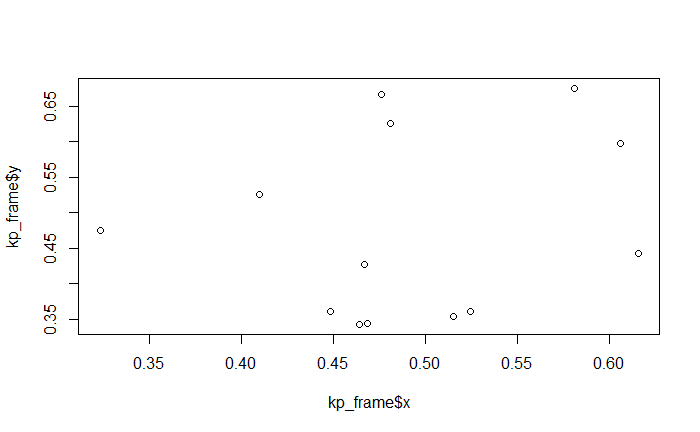

```r
plot(x = kp_frame$x,
     y = kp_frame$y)
```

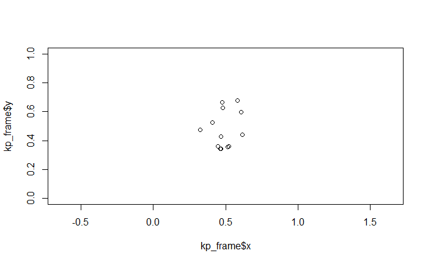

```r
plot(x = kp_frame$x,
     y = kp_frame$y,
     xlim = c(0, 1),
     ylim = c(0, 1),
     asp = 1)
```

[figure not shown]

```r
kp_frame$y_rev <- -kp_frame$y

plot(x = kp_frame$x,
     y = kp_frame$y,
     asp = 1,
     xlim = c(0, 1),
     ylim = c(1, 0),
     axes = T)

polygon(x = c(0, 1, 1, 0),
        y = c(720/1296+0.25, 720/1296+0.25, 0.25, 0.25),
        col = alpha("grey75", 1),
        border = "grey75")
```

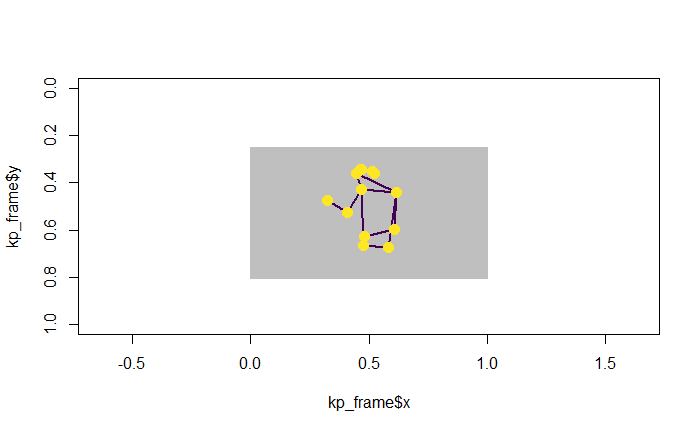

```r
for (e in 1:length(edges)) {
  p1 <- kp_frame[edges[[e]][1], c("x", "y")]
  p2 <- kp_frame[edges[[e]][2], c("x", "y")]

  if (all(!is.na(p1)) & all(!is.na(p2))) {
    segments(
      x0 = as.numeric(p1$x),
      y0 = as.numeric(p1$y),
      x1 = as.numeric(p2$x),
      y1 = as.numeric(p2$y),
      lwd = 2,
      col = viridis(2)[1]
    )
  }
}

points(x = kp_frame$x,
       y = kp_frame$y,
       pch = 19,
       cex = 1.5,
       col = viridis(2)[2])
```

```r
 # load image
image <- load.image("frames_speech2/frame00001.png")
```

[output not shown]

# Calculate measure of gesticulation

```r
# (1) extract column names of x- and y- choordinates of keypoints
get_kp_x_cols <- function(colnames){
  colnames[str_detect(colnames, "kp[:digit:]+\\_x$")]
}

get_kp_y_cols <- function(colnames, scaled = T){
  colnames[str_detect(colnames, "kp[:digit:]+\\_y$")]
}
```

[output not shown]

[output cut: 264 more lines]

[output not shown]

[output cut: 264 more lines]

```r
# Gesticulation speech 2
mean(c(speech2_keypoints$left_wrist_movement,
       speech2_keypoints$right_wrist_movement),
     na.rm = T)
```

```
[1] 0.01500968
```

# Calculate measure of posture

```r
calculate_wrist_height <- function(kp_data){

  # left shoulder: kp6
  # left wrist: kp10
  # right shoulder: kp7
  # right wrist: kp11

  # left height:
  kp_data$left_wrist_height <- kp_data$kp6_y - kp_data$kp10_y

  # right wrist height:
  kp_data$right_wrist_height <- kp_data$kp7_y - kp_data$kp11_y

  # height of the higher wrist
  kp_data$max_wrist_height <-
    apply(kp_data[, c("left_wrist_height", "right_wrist_height")], 1, max)

  return(kp_data)
}
```

```r
speech1_keypoints <- calculate_wrist_height(speech1_keypoints)
speech2_keypoints <- calculate_wrist_height(speech2_keypoints)
```

```r
mean(speech2_keypoints$max_wrist_height)
```

```
[1] -0.05291393
```